# Assignment: End-to-End Machine Learning Project

The material in this assignment is based on Chapter 2 of Hands-On Machine Learning with Scikit-Learn and TensorFlow, by Aurelien Geron.

# What problem are we trying to solve and how will we solve it?

In our case, we will be trying to build a model of California housing prices using Census data. The primary goal: be able to predict the median housing price in any California district, using the data available in this dataset. This problem is an example of **regression**, where the prediction of our model (or its output) is a continuous variable. This is in contrast to **classification**, where the prediction of our model (or its output) is a class or group.

The data description can be found here: https://github.com/ageron/handson-ml2/tree/master/datasets/housing

The data file itself is in data/housing.csv, found in the ./data directory of this module.

The typical steps in such an analysis vary depending on the problem, but they usually include the following:

- Get the data.
- Data preparation and visualization
  - Minimally clean and prepare the data.
  - Explore the data, typically using visualizations.
- Select a model appropriate for your particular problem and train it.
- Test the model using unseen data.
- Possibly fine tune the model.
- Present the results.

We will go through all of these steps. We won't dwell on the details of the model - we will use it like a **black box**. Later on in the course, we will spend more time on the details.

In the code blocks below, we sometime give some hints on how to start. In other cases, we point you back to previous examples.

# Info on the Data

This dataset is a modified version of the California Housing dataset available from Luís Torgo's page (University of Porto). Luís Torgo obtained it from the StatLib repository (which is closed now). The dataset may also be downloaded from StatLib mirrors.

This dataset appeared in a 1997 paper titled Sparse Spatial Autoregressions by Pace, R. Kelley and Ronald Barry, published in the Statistics and Probability Letters journal. They built it using the 1990 California census data. It contains one row per census block group. A block group is the smallest geographical unit for which the U.S. Census Bureau publishes sample data (a block group typically has a population of 600 to 3,000 people).

## Task 1: Get the data and print the colums

The location of the data file we want to use is here:

`/fs/ess/PAS2038/PHYSICS_5680_OSU/class_data/module1/housing.csv`

```python
import pandas as pd
import plotly.io as pio
pio.renderers.default='plotly_mimetype'

# Now let's print some data to the screen
df_housing = pd.read_csv('/fs/ess/PAS2038/PHYSICS_5680_OSU/class_data/module1/housing.csv')
print("Housing columns:",df_housing.columns)
```

```
Housing columns: Index(['longitude', 'latitude', 'housing_median_age', 'total_rooms',
       'total_bedrooms', 'population', 'households', 'median_income',
       'median_house_value', 'ocean_proximity'],
      dtype='object')
```

## Make a copy of the categorical variable

We do this here for you just in case you want access to the original.

```python
#
# By default get_dummies drops the original column, so let's make a copy
df_housing['ocean_proximity_original'] = df_housing['ocean_proximity']
```

## Task 2: Explore the data

As we did in earlier notebooks, we are going to want to explore the data.

1. Look at a few rows of the dataset: use df_housing.head().
2. Get some info about the names and types of the columns in the dataframe, the number of rows, and how much memory the dataframe takes up: using df_housing.info()
3. Get some basic statistical info about the dataframe (mean, std, etc): use df_housing.describe()
4. Get correlations among all of the columns: use df_housing.corr()

```python
#
# We start this for you...
print("HEAD:")
print(df_housing.head())
print()
print("INFO:")
print(df_housing.info())
print()
print("DESCRIBE:")
print(df_housing.describe())
print()
print("CORRELATION:")
print(df_housing.corr(numeric_only=True))
```

```
HEAD:
   longitude  latitude  housing_median_age  total_rooms  total_bedrooms  \
0    -122.23     37.88                41.0        880.0           129.0
1    -122.22     37.86                21.0       7099.0          1106.0
2    -122.24     37.85                52.0       1467.0           190.0
3    -122.25     37.85                52.0       1274.0           235.0
4    -122.25     37.85                52.0       1627.0           280.0

   population  households  median_income  median_house_value ocean_proximity  \
0       322.0       126.0         8.3252            452600.0        NEAR BAY
1      2401.0      1138.0         8.3014            358500.0        NEAR BAY
2       496.0       177.0         7.2574            352100.0        NEAR BAY
3       558.0       219.0         5.6431            341300.0        NEAR BAY
4       565.0       259.0         3.8462            342200.0        NEAR BAY

  ocean_proximity_original
0                 NEAR BAY
1                 NEAR BAY
2                 NEAR BAY
3                 NEAR BAY
4                 NEAR BAY

INFO:
<class 'pandas.core.frame.DataFrame'>
RangeIndex: 20640 entries, 0 to 20639
Data columns (total 11 columns):
 #   Column                    Non-Null Count  Dtype
---  ------                    --------------  -----
 0   longitude                 20640 non-null  float64
 1   latitude                  20640 non-null  float64
 2   housing_median_age        20640 non-null  float64
 3   total_rooms               20640 non-null  float64
 4   total_bedrooms            20433 non-null  float64
 5   population                20640 non-null  float64
 6   households                20640 non-null  float64
 7   median_income             20640 non-null  float64
 8   median_house_value        20640 non-null  float64
 9   ocean_proximity           20640 non-null  object
 10  ocean_proximity_original  20640 non-null  object
dtypes: float64(9), object(2)
```

[output cut: 52 more lines]

```
population                0.877747    1.000000    0.907222       0.004834
households                0.979728    0.907222    1.000000       0.013033
median_income            -0.007723    0.004834    0.013033       1.000000
median_house_value        0.049686   -0.024650    0.065843       0.688075

                    median_house_value
longitude                    -0.045967
latitude                     -0.144160
housing_median_age            0.105623
total_rooms                   0.134153
total_bedrooms                0.049686
population                   -0.024650
households                    0.065843
median_income                 0.688075
median_house_value            1.000000
```

## Task 2A: Comment on two features which are most correlated with median_house_value

Give a 1-3 sentence description of the two features which have the highest (independent of sign) correlation with median_house_value. Do these make sense?

YOUR RESPONSE: Based on the provided correlation data, the two features most correlated with median house value are median income and latitude. The correlation with median income is the strongest and it makes sense because higher income generally allows people to afford more expensive homes. The correlation with latitude is also notable, although it is negative. This suggests that as latitude increases (moving north in California), housing prices tend to decrease, which is logical given that major cities like Los Angeles and San Diego are located at lower latitudes.

Official answer: The two features with the highest correlation with median_house_value are:

1. median_income: This has the highest correlation, which makes sense since if the median income is higher, then residents can afford more expensive homes.
2. latitude: The correlation is not so strong here and it is negative, but this makes sense - the higher the latitude the further from areas like Los Angeles and San Diego, and thus the cheaper the homes.
3. total_rooms: This is another possibility. Again the correlation is not strong, and it is positive. This makes sense as the more rooms, the higher the value of the house.

## Task 3: Histogram each column

There are 11 columns, so you can do this with 11 lines of code.

But.. can you do this using a simple for loop? That would be better!

Either approach is fine. Remember you can ask gemini: "How can I histogram all of the columns of a dataframe using plotly?"

```
array([[<Axes: title={'center': 'longitude'}>,
        <Axes: title={'center': 'latitude'}>,
        <Axes: title={'center': 'housing_median_age'}>],
       [<Axes: title={'center': 'total_rooms'}>,
        <Axes: title={'center': 'total_bedrooms'}>,
        <Axes: title={'center': 'population'}>],
       [<Axes: title={'center': 'households'}>,
        <Axes: title={'center': 'median_income'}>,
        <Axes: title={'center': 'median_house_value'}>]], dtype=object)
```

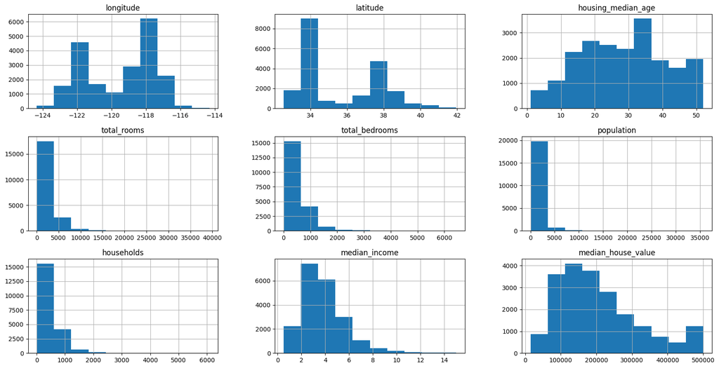

```python
import plotly.express as px

df_housing.hist(figsize=(20,10))
# Your code here
```

## Task 4: Make a scatter plot

Our goal in this assignment: predict the **median_house_value** given all of the other data. "median_house_value" will be our label (or the target). All of the other columns are our **features**.

Scatter plot median_house_value vs median_income. We **know** that this is highly correlated (from the above .corr output).

```python
import plotly.io as pio
pio.renderers.default = 'plotly_mimetype+notebook'
fig = px.scatter(df_housing, x='median_income', y='median_house_value', title='Median House Value vs. Median Income')
fig.show()
```

[interactive chart not shown]

## Task 4A: Comment on above figure.

Give a 1-3 sentence description of how median house income varies with median income, for the "blocks" in the data.

YOUR RESPONSE: The scatter plot shows a strong positive relationship between median_house_value and median_income. It's clear that as the median income of a block increases, the median house value tends to increase as well. However, there's also a noticeable cluster of points forming a horizontal line at the top of the plot. This indicates that many houses have a median value capped around $500,000, regardless of the income in that area.

## Task 5: Feature Engineering

Feature engineering refers to combining existing features to form new ones. These combinations might be simple (like the result of adding/subracting/multiplying/etc) or they could be more complex - like the results of a sophisticated analysis. The basic idea is to add information for each candidate data point, which will hopefully improve whatever model we end up using to perform our predictions.

Create the following features:

1. rooms_per_household
2. bedrooms_per_household
3. bedrooms_per_room
4. people_per_household

Below we should how to make the first new feature. You should add the other 3.

```python
#
# The first one is done for you - this code adds a new column called 'rooms_per_household' based on the
# value of two other columns
df_housing['rooms_per_household'] = df_housing['total_rooms']/df_housing['households']
#
# Now do the other 3
df_housing['bedrooms_per_household'] = df_housing['total_bedrooms'] / df_housing['households']
df_housing['bedrooms_per_room'] = df_housing['total_bedrooms'] / df_housing['total_rooms']
df_housing['people_per_household'] = df_housing['population'] / df_housing['households']
```

```python
fig = px.histogram(df_housing, x='rooms_per_household')
fig.show()
```

[interactive chart not shown]

## Task 6: Dealing with missing data

We have two options:

1. Removing all rows with any missing data
2. Replacing the missing data with the mean of the column: **NOTE**: if you do this, you must get the means from the **training** set. Think about why this is the case.

Let use dropping all rows with any missing data.

```python
print("Length of housing DF before dropping NA:",len(df_housing))

# Your code here
df_housing.dropna(inplace=True)
print("Length of housing DF after dropping NA:", len(df_housing))
```

```
Length of housing DF before dropping NA: 20640
Length of housing DF after dropping NA: 20433
```

## Task 7: One-hot encoding

The 'ocean_proximity' variable is a text variable, that we will want to **one-hot** encode. Look at "How get_dummies Works" in the module1_intro_multi_lin_regres notebook.

```python
#
# Get all of the column names right before using get_dummies!!!!
columns_before_get_dummies = df_housing.columns.tolist()
#
# Now run get_dummies
df_housing = pd.get_dummies(df_housing, columns=['ocean_proximity'], dtype=float)
```

## Task 8: Train/Test Splitting

Out goal is to design an algorithm to predict housing prices. To test our model, we will want to split our data into two parts:

1. Training sample: This is the sample we will train our model on.
2. Testing sample: This is the **unseen** data that we will test our trained model on. Good performance on this sample will ensure that our model generalizes well.

NOTE: Given the above scatter plot of median_house_value vs median_income, we see that there is a strong band at median_house_value=500,000. So lets remove those samples from our data we split the data into test and train subsamples.

Require that all of our samples have housing['median_house_value']<499999 **BEFORE** doing your test/train split.

```python
import numpy as np
from sklearn.model_selection import train_test_split
df_housing = df_housing[df_housing['median_house_value'] < 499999]
df_housing["income_cat"] = pd.cut(df_housing["median_income"], bins=[0., 1.5, 3.0, 4.5, 6.0, np.inf], labels=[1, 2, 3, 4, 5])
df_housing_train, df_housing_test = train_test_split(df_housing, test_size=0.2, random_state=42, stratify=df_housing["income_cat"])
```

## Task 9: Extract the one-hot encoded columns for train and test into their own dataframes

We will need just the one-hot encoded columns for both the train and test samples in separate dataframes.

Let's make those now.

```python
# modify this code
one_hot_columns = ['ocean_proximity_<1H OCEAN', 'ocean_proximity_INLAND', 'ocean_proximity_ISLAND', 'ocean_proximity_NEAR BAY', 'ocean_proximity_NEAR OCEAN']
df_train_onehot = df_housing_train[one_hot_columns].copy()
df_test_onehot = df_housing_test[one_hot_columns].copy()
```

## Task 10: Feature Scaling and Transformation

We will use feature scaling as we did with the flight dataset.

In this case, only use **MinMaxScaler**. Remember: you need to use the **training** set to **fit** the transformer, and you need to use the **transformer** on **both** the training and test sets.

An example of how to do this for multiple columns is in the inclass_module1 notebook in the section **Min-Max scaling and sci-kit learn estimators**.

Remember that we do not use these techniques for **categorical** or **object/text**.

To figure out which columns are which, use the code below:

```python
print("housing column types:")
print(df_housing.dtypes)
```

```
housing column types:
longitude                      float64
latitude                       float64
housing_median_age             float64
total_rooms                    float64
total_bedrooms                 float64
population                     float64
households                     float64
median_income                  float64
median_house_value             float64
ocean_proximity_original        object
rooms_per_household            float64
bedrooms_per_household         float64
bedrooms_per_room              float64
people_per_household           float64
ocean_proximity_<1H OCEAN      float64
ocean_proximity_INLAND         float64
ocean_proximity_ISLAND         float64
ocean_proximity_NEAR BAY       float64
ocean_proximity_NEAR OCEAN     float64
income_cat                    category
dtype: object
```

I ended up using the following columns for input to my minmax scaler, and I suggest you do the same:

["housing_median_age","total_rooms","total_bedrooms", "population","households","median_income", "rooms_per_household","bedrooms_per_household","bedrooms_per_room", "people_per_household"]

```python
from sklearn.preprocessing import MinMaxScaler
scaler = MinMaxScaler()
#
# fit AND transform the training data!
print(df_housing_train.columns)
columns_to_transform = ["housing_median_age","total_rooms","total_bedrooms",
                                 "population","households","median_income",
                                  "rooms_per_household","bedrooms_per_household","bedrooms_per_room",
                                  "people_per_household"]

# copy the relevant code from the section "Min-Max scaling" in the module1_intro_multi_lin_regres notebook below
df_train_scaled = df_housing_train[columns_to_transform].copy()
df_test_scaled = df_housing_test[columns_to_transform].copy()

scaler.fit(df_train_scaled)

scaled_train_features = scaler.transform(df_train_scaled)
scaled_test_features = scaler.transform(df_test_scaled)

df_train_scaled = pd.DataFrame(scaled_train_features, columns=columns_to_transform, index=df_train_scaled.index)
df_test_scaled = pd.DataFrame(scaled_test_features, columns=columns_to_transform, index=df_test_scaled.index)
```

```
Index(['longitude', 'latitude', 'housing_median_age', 'total_rooms',
       'total_bedrooms', 'population', 'households', 'median_income',
       'median_house_value', 'ocean_proximity_original', 'rooms_per_household',
       'bedrooms_per_household', 'bedrooms_per_room', 'people_per_household',
       'ocean_proximity_<1H OCEAN', 'ocean_proximity_INLAND',
       'ocean_proximity_ISLAND', 'ocean_proximity_NEAR BAY',
       'ocean_proximity_NEAR OCEAN', 'income_cat'],
      dtype='object')
```

## Task 11: Combining everything before fitting

Refer to the section in the module1_intro_multi_lin_regres workbook titled "Putting Humpty-Dumpty back together!""

```python
#
# Step 1: Make the full training dataframe
#
# To concat across columns safeley, we need to reset the indexes!
df_housing_train_toFit = pd.concat([df_train_scaled.reset_index(drop=True), df_train_onehot.reset_index(drop=True)], axis=1)

#
# Step 2: Make the full testing dataframe
df_housing_test_toFit = pd.concat([df_test_scaled.reset_index(drop=True), df_test_onehot.reset_index(drop=True)], axis=1)

#
# Step 3: Get the train and test labels
train_housing_labels = df_housing_train['median_house_value'].reset_index(drop=True)
test_housing_labels = df_housing_test['median_house_value'].reset_index(drop=True)

#
# Some printout
print("shape train labels", train_housing_labels.shape)
print("shape train features", df_housing_train_toFit.shape)
print("shape test labels", test_housing_labels.shape)
print("shape test features", df_housing_test_toFit.shape)
print(df_housing_train_toFit.columns)
print(df_housing_test_toFit.columns)
```

```
shape train labels (15558,)
shape train features (15558, 15)
shape test labels (3890,)
shape test features (3890, 15)
Index(['housing_median_age', 'total_rooms', 'total_bedrooms', 'population',
       'households', 'median_income', 'rooms_per_household',
       'bedrooms_per_household', 'bedrooms_per_room', 'people_per_household',
       'ocean_proximity_<1H OCEAN', 'ocean_proximity_INLAND',
       'ocean_proximity_ISLAND', 'ocean_proximity_NEAR BAY',
       'ocean_proximity_NEAR OCEAN'],
      dtype='object')
Index(['housing_median_age', 'total_rooms', 'total_bedrooms', 'population',
       'households', 'median_income', 'rooms_per_household',
       'bedrooms_per_household', 'bedrooms_per_room', 'people_per_household',
       'ocean_proximity_<1H OCEAN', 'ocean_proximity_INLAND',
       'ocean_proximity_ISLAND', 'ocean_proximity_NEAR BAY',
       'ocean_proximity_NEAR OCEAN'],
      dtype='object')
```

## Task 12: Fit the data and test the fit

As before the fit model will be linear regression (we are using more than just a single feature but is it still just linear regression).

So:

1. Fit the data
2. Apply the fit to both the Train and Test data
3. Calculate the RMSE for both the Train and Test data

```python
from sklearn.linear_model import LinearRegression
from sklearn.metrics import mean_squared_error
import numpy as np

model = LinearRegression()
model.fit(df_housing_train_toFit, train_housing_labels)

train_predictions = model.predict(df_housing_train_toFit)
train_mse = mean_squared_error(train_housing_labels, train_predictions)
train_rmse = np.sqrt(train_mse)

test_predictions = model.predict(df_housing_test_toFit)
test_mse = mean_squared_error(test_housing_labels, test_predictions)
test_rmse = np.sqrt(test_mse)

print(f"Train RMSE: {train_rmse}")
print(f"Test RMSE: {test_rmse}")
```

```
Train RMSE: 60282.49770596055
Test RMSE: 61494.025206172424
```

## Task 12A: Comment on the RMSE of the Testing Data

Give a 1-3 sentence description of the RMSE of the test data. Is it reasonable? Compare it to the median of the median_house_value (this is printed out above in Task 2: Explore the data).

YOUR RESPONSE: The Test RMSE is approximately $61,494.03.$ This value is reasonable when you consider the median house value of $179,700.$ The RMSE represents the typical error of our predictions, meaning that on average, the model's predictions are off by about a third of the median house price. This level of error is acceptable for this type of linear regression model.

## Task 13: Plot residual vs predicted value

Make a scatter plot of the residual for both the test and train samples.

```python
import plotly.express as px

train_residuals = train_housing_labels - train_predictions
test_residuals = test_housing_labels - test_predictions

train_plot_df = pd.DataFrame({'Predicted Value': train_predictions, 'Residual': train_residuals})
test_plot_df = pd.DataFrame({'Predicted Value': test_predictions, 'Residual': test_residuals})

fig_train = px.scatter(train_plot_df, x='Predicted Value', y='Residual', title='Training Data: Residual vs. Predicted Value')
fig_train.show()

fig_test = px.scatter(test_plot_df, x='Predicted Value', y='Residual', title='Testing Data: Residual vs. Predicted Value')
fig_test.show()
```

[interactive chart not shown]

## Task 14: Feature Importance

Your goal for this task is to print the coefficient names and their values.

- Which coefficients are the largest?
- Do these make sense?

```python
feature_names = df_housing_train_toFit.columns

coefficients = model.coef_

feature_importance_df = pd.DataFrame({'Feature': feature_names, 'Coefficient': coefficients})
feature_importance_df['Absolute_Coefficient'] = np.abs(feature_importance_df['Coefficient'])
feature_importance_df = feature_importance_df.sort_values(by='Absolute_Coefficient', ascending=False)

print(feature_importance_df)
```

```
                       Feature   Coefficient  Absolute_Coefficient
3                   population -1.066731e+06          1.066731e+06
6          rooms_per_household  8.795511e+05          8.795511e+05
7       bedrooms_per_household -8.475899e+05          8.475899e+05
5                median_income  6.112719e+05          6.112719e+05
4                   households  5.945935e+05          5.945935e+05
8            bedrooms_per_room  3.141553e+05          3.141553e+05
12      ocean_proximity_ISLAND  2.047534e+05          2.047534e+05
11      ocean_proximity_INLAND -9.931633e+04          9.931633e+04
2               total_bedrooms  5.383738e+04          5.383738e+04
0           housing_median_age  5.341933e+04          5.341933e+04
10   ocean_proximity_<1H OCEAN -4.037596e+04          4.037596e+04
13    ocean_proximity_NEAR BAY -3.719545e+04          3.719545e+04
14  ocean_proximity_NEAR OCEAN -2.786570e+04          2.786570e+04
1                  total_rooms -1.822276e+04          1.822276e+04
9         people_per_household -1.046260e+03          1.046260e+03
```

The largest coefficients (by absolute value) are for population, rooms per household, bedrooms per household, and median income. These results largely make sense.

## Extra Challenge: Some extra stuff: NOT REQUIRED FOR THE ASSIGNMENT

If you are looking for more to do! This is not required as part of the assignment.

1. We probably should have done this first.... but how do we *know* that our fit improved our knowledge? Is there a simple predictor that we could have used instead? How about if we predict the price simply based on the mean (or the median) of all housing prices? Use the mean squared error to do this.
2. Try another predictor from sklearn: RandomForestRegressor and/or DecisionTreeRegressor. Make sure you test the fit results (using mean_squared_error) on BOTH the training AND test sets!

## Extra Challenge:

1. We probably should have done this first.... but how do we *know* that our fit improved our knowledge? Is there a simple predictor that we could have used instead? How about if we predict the price simply based on the mean (or the median) of all housing prices? Use the mean squared error to do this.

## Extra Challenge Part 1A: Comment on the RMSE Results When Using the Average

Give a 1-3 sentence description of the RMSE of the test data of when using the average value of the training sample as our prediction.  
Is it reasonable? Compare it to the RMSE we got when doing a Linear Regression on the full data. Did using Linear Regression help?

## Extra Challenge Part 2:

Try another predictor from sklearn: RandomForestRegressor and/or DecisionTreeRegressor. Make sure you test the fit results (using mean_squared_error) on BOTH the training AND test sets!

NOTE: There may be a big difference between test and train RMSE in this case(which we did not see above).

## Extra Challenge Part 2A: Comment on the RMSE on both Test and Train Results When Using the RandomForestRegressor

Give a 1-3 sentence description of the RMSE of both Test and Train Results When Using the RandomForestRegressor. Compare it to the RMSE we got when doing Linear Regression.